# Testing primers against PR2

Daniel Vaulot

10 04 2019

# 1 Goal

- Testing primers against the PR2 database (latest version 4.11.1)

# 2 Notes about script

- Chunks `compute_matches` and `store_matches` have only to be run in 2 cases
  - new version of pr2
  - new set of primers
  - In the other case, they can be set eval=FALSE

## 2.1 To do

- Use degenerated primers to locate the V4 and V9 region
- Check why there are some negative amplicon (probably some matches ahead - Put a condition that amplicon should be >)

## 2.2 References used

- https://bioconductor.statistik.tu-dortmund.de/packages/3.4/bioc/vignettes/IRanges/inst/doc/IRangesOverview.pdf
- http://kasperdanielhansen.github.io/genbioconductor/

# 3 Initialize

Load the variables common to the different scripts and the necessary libraries

```r
  source('PR2_init.R', echo=FALSE)
  knitr::opts_chunk$set(cache=TRUE)
```

# 4 Read pr2 (version 4.11.1)

Remove * Any sequence not in PR2 * Any sequence with ambuiguities

```r
data(pr2)
pr2_active <- pr2 %>% filter(is.na(removed_version)) %>% filter(!str_detect(sequence,
    pr2.env$ambig_regex))
```

# 5 Read primer file

```r
primer_sets <- read_excel(path = "../primers/primers_18S.xlsx", sheet = "primer sets")
knitr::kable(select(primer_sets, region:rev_pos)) %>% kableExtra::kable_styling()
```

| region | primer_set_id | primer_set_name | fwd_id | fwd_name | fwd_seq | fwd_pos | rev_id | rev_name | rev_seq | rev_pos |
| --- | --- | --- | --- | --- | --- | --- | --- | --- | --- | --- |
| V4 | 1 | NA | 1 | F-566 | CAGCAGCCGCGGTAATTCC | NA | 1 | R-1200 | CCCGTGTTGAGTCAAATTAAGC | NA |
| V4 | 2 | NA | 2 | F-574 | GCGGTAATTCCAGCTCCAA | NA | 2 | R-952 | TTGGCAAATGCTTTCGC | NA |
| V4 | 3 | NA | 3 | 574*f | CGGTAAYTCCAGCTCYV | NA | 3 | 1132r | CCGTCAATTHCTTYAART | NA |
| V4 | 4 | NA | 4 | 563f | GCCAGCAVCYGCGGTAAY | NA | 3 | 1132r | CCGTCAATTHCTTYAART | NA |
| V4 | 5 | NA | 5 | 616f | TTAAAAVGYTCGTAGTYG | NA | 3 | 1132r | CCGTCAATTHCTTYAART | NA |
| V4 | 6 | NA | 6 | 616*f | TTAAARVGYTCGTAGTYG | NA | 3 | 1132r | CCGTCAATTHCTTYAART | NA |
| V4 | 7 | NA | 7 | V4_1f | CCAGCASCYGCGGTAATWCC | NA | 4 | TAReukREV3 | ACTTTCGTTCTTGATYRA | NA |
| V4 | 8 | NA | 8 | TAReuk454FWD1 | CCAGCASCYGCGGTAATTCC | NA | 4 | TAReukREV3 | ACTTTCGTTCTTGATYRA | NA |
| V4 | 9 | NA | 9 | Euk528F | CGGTAATTCCAGCTCC | NA | 5 | U1492R | GGTTACCTTGTTACGACTT | NA |
| V4 | 10 | NA | 9 | Euk528F | CGGTAATTCCAGCTCC | NA | 6 | U1391R | GGGCGGTGTGTACAARGR | NA |
| V4 | 11 | NA | 9 | Euk528F | CGGTAATTCCAGCTCC | NA | 7 | U1517R | ACGGCTACCTTGTTACGACTT | NA |
| V4 | 12 | NA | 10 | 3NDF | GGCAAGTCTGGTGCCAG | NA | 8 | 1132r | CCGTCAATTHCTTYAART | NA |
| V4 | 13 | NA | 10 | 3NDF | GGCAAGTCTGGTGCCAG | NA | 9 | V4_euk_R1 | GACTACGACGGTATCTRATCRTCTTCG | NA |
| V4 | 14 | NA | 10 | 3NDF | GGCAAGTCTGGTGCCAG | NA | 10 | V4_euk_R2 | ACGGTATCTRATCRTCTTCG | NA |
| V4 | 15 | NA | 11 | EUKAF | GCCGCGGTAATTCCAGCTC | NA | 11 | EUKAR | CYTTCGYYCTTGATTRA | NA |
| V4 | 16 | Piredda | 12 | V4 18S Next.For / BioMarKs V4 | CCAGCASCYGCGGTAATTCC | NA | 12 | V4 18S Next.Rev | ACTTTCGTTCTTGATYRATGA | NA |
| V4 | 17 | Comeau | 13 | E572F | CYGCGGTAATTCCAGCTC | NA | 13 | E1009R | AYGGTATCTRATCRTCTTYG | NA |
| V4 | 18 | NA | 14 | 515f | GTGCCAGCMGCCGCGGTAA | NA | 14 | 1119r | GGTGCCCTTCCGTCA | NA |
| V4 | 19 | NA | 15 | Claudia Vannini FW | CCAGCASCCGCGGTAATWCC | NA | 15 | Claudia Vannini rev | TARGGGATCAAAGACRAYCAGA | NA |
| V4 | 20 | NA | 16 | Jens Boenigk 454 austrian lakesfw | ATTCCAGCTCCAATAGCG | NA | 16 | Jens Boenigk 454 austrian lakesrev | GATTAGATACCATCGTAGTC | NA |
| V4 | 21 | NA | 17 | D512for | ATTCCAGCTCCAATAGC | NA | 17 | D978rev | GATTAATACCATCGTAGTC | NA |
| V4 | 22 | NA | 18 | Nex_18S_0587_F | CCGCGGTAATTCCAGCTC | NA | 18 | Nex_18S_0964_R | GATCCCYYAACTTTCGTTCTTGA | NA |
| V4 | 23 | NA | 19 | 590F | CGGTAATTCCAGCTCCAATAGC | NA | 19 | 1300R | CACCAACTAAGAACGGCCATGC | NA |
| V4 | 24 | NA | 20 | EK-565F-NGS | GCAGTTAAAAAGCTCGTAGT | NA | 20 | UNonMetR | TTTAAGTTTCAGCCTTGCG | NA |
| V4 | 25 | NA | 21 | NSF563 | CGCGGTAATTCCAGCTCCA | NA | 21 | NSR951 | TTGGYRAATGCTTTCGC | NA |
| V4 | 26 | NA | 22 | S6 | ccgcggtaattccagctc | NA | 22 | S12.2R | gactacgacggtatctratc | NA |
| V4 | 34 | NA | 30 | 515F Univ short | GTGYCAGCMGCCGCGGTA | NA | 21 | NSR951 | TTGGYRAATGCTTTCGC | NA |
| V4 | 35 | NA | 31 | UNonMetF | GTGCCAGCAGCCGCG | NA | 18 | UNonMetR | TTTAAGTTTCAGCCTTGCG | NA |
| V9 | 27 | NA | 23 | 1391F | GTACACACCGCCCGTC | NA | 23 | EukB | TGATCCTTCTGCAGGTTCACCTAC | NA |
| V9 | 28 | NA | 24 | 1380F | CCCTGCCHTTTGTACACAC | NA | 24 | 1510R | CCTTCYGCAGGTTCACCTAC | NA |
| V9 | 29 | NA | 25 | 1389F | TTGTACACACCGCCC | NA | 24 | 1510R | CCTTCYGCAGGTTCACCTAC | NA |
| V9 | 30 | NA | 26 | Lane 1991 | GTACACACCGCCCGTC | NA | 25 | ITS2_broad | GCTGCGTTCTTCATCGWTR | NA |
| V9 | 31 | NA | 27 | 1388F | TTGTACACACCGCCCGTCGC | NA | 24 | 1510R | CCTTCYGCAGGTTCACCTAC | NA |
| Universal | 32 | NA | 28 | 926wF | AAACTYAAAKGAATTGRCGG | NA | 26 | 1392-R | ACGGGCGGTGTGTRC | NA |
| Universal | 33 | NA | 29 | 515f Univ | GTGYCAGCMGCCGCGGTAA | NA | 27 | 926R | CCGYCAATTYMTTTRAGTTT | NA |

```r
knitr::kable(select(primer_sets, region, primer_set_id, used_in:remark)) %>%
    kableExtra::kable_styling()
```

| region | primer_set_id | used_in | reference | remark |
| --- | --- | --- | --- | --- |
| V4 | 1 | NA | Hadziavdic et al. (2014) PLoS ONE 9, e87624. | NA |
| V4 | 2 | NA | Hadziavdic et al. (2014) PLoS ONE 9, e87624. | NA |
| V4 | 3 | NA | Hugerth et al. (2014) PLoS ONE 9, e95567. | NA |
| V4 | 4 | NA | Hugerth et al. (2014) PLoS ONE 9, e95567. | NA |
| V4 | 5 | NA | Hugerth et al. (2014) PLoS ONE 9, e95567. | NA |
| V4 | 6 | NA | Hugerth et al. (2014) PLoS ONE 9, e95567. | NA |
| V4 | 7 | NA | Bass et al. (2016) Environmental Microbiology 18, 1604–1619. | NA |
| V4 | 8 | NA | Stoeck et al (2010) Mol. Ecol. 19, 21-31. | NA |
| V4 | 9 | NA | Edgcomb et al. (2011) ISME J. 5, 1344-1356. | NA |
| V4 | 10 | NA | Edgcomb et al. (2011) ISME J. 5, 1344-1356. | NA |
| V4 | 11 | NA | Edgcomb et al. (2011) ISME J. 5, 1344-1356. | NA |
| V4 | 12 | NA | Geisen et al Meth Ecol Evol in press | NA |
| V4 | 13 | NA | Bråte et al. (2010) The Isme Journal 4: 1144. | NA |
| V4 | 14 | NA | Bråte et al. (2010) The Isme Journal 4: 1144. | NA |
| V4 | 15 | NA | Moreno et al. (2018) International Journal of Hygiene and Environmental Health 221: 102-111. | NA |
| V4 | 16 | Ocean Sampling Day | R. Pireddaet al. (2017) FEMS Microbiology Ecology, Volume 93(1):1 | NA |
| V4 | 17 | NA | Comeau et al. (2011) PLoS ONE 6, e27492. | The sequence mentionned in the paper CRAAGAYGATYAGATACCRT (Table S1) is the matching gene sequence not the primer sequence |
| V4 | 18 | NA | Parfrey et al. 2014 frontiers microbiol | NA |
| V4 | 19 | NA | NA | NA |
| V4 | 20 | NA | NA | NA |
| V4 | 21 | NA | Hervé et al. 2017, 10.1038/ismej.2017.166 | NA |
| V4 | 22 | NA | Kim et al. 2016 EMI | NA |
| V4 | 23 | NA | Venter et al 2017 Protist | NA |
| V4 | 24 | NA | Simon et al. 2015 EMI (and ISME) | NA |
| V4 | 25 | NA | Mangot JF, Domaizon I, Taib N, Marouni N, Duffaud E, Bronner G, Debroas D (2013) Environ Microbiol 15:1745–1758. | NA |
| V4 | 26 | NA | Pawlowski and Smirnov unpublished | NA |
| V4 | 34 | NA | Lambert et al. ISME 2018 | NA |
| V4 | 35 | NA | Bower SM et al. J Eukaryot Microbiol. 2004;51:325–32 | NA |
| V9 | 27 | NA | Stoeck et al (2010) Mol. Ecol. 19, 21-31; primers from Lane 1991 and Medlin 1988 | NA |
| V9 | 28 | NA | Amaral Zettler et al (2009) Plos One | NA |
| V9 | 29 | Tara Oceans | Amaral Zettler et al (2009) Plos One | NA |
| V9 | 30 | NA | Boenigk et al. 2018 MBMG | NA |
| V9 | 31 | NA | R. Piredda, M. P. Tomasino, A. M. D’Erchia, C. Manzari, G. Pesole, M. Montresor, W. H. C. F. Kooistra, D. Sarno, A. Zingone (2017) FEMS Microbiology Ecology, Volume 93(1):1 | NA |
| Universal | 32 | NA | Wilkins, D., et l.. 2013. Nat. Commun. 4:2457. | NA |
| Universal | 33 | NA | Needham, D.M. & Fuhrman, J.A. 2016. Nat. Microbiol. 1–7. | NA |

# 6 Computing the matches

## 6.1 Programing Notes

- Use Biostrings

Accessor methods : In the code snippets below, x is an MIndex object.

- length(x): The number of patterns that matches are stored for.
- names(x): The names of the patterns that matches are stored for.
- startIndex(x): A list containing the starting positions of the matches for each pattern.
- endIndex(x): A list containing the ending positions of the matches for each pattern.
- elementNROWS(x): An integer vector containing the number of matches for each pattern.
- x[[i]]: Extract the matches for the i-th pattern as an IRanges object.
- unlist(x, recursive=TRUE, use.names=TRUE): Return all the matches in a single IRanges object. recursive and use.names are ignored.
- extractAllMatches(subject, mindex): Return all the matches in a single XStringViews object.

One could also use another function which does not give the position * match_fwd <- vcountPattern(fwd, seq,max.mismatch=0, min.mismatch=0, with.indels=FALSE, fixed=FALSE, algorithm=“auto”)

```r
# Set 7
 fwd = DNAString("CCAGCASCYGCGGTAATWCC")
 rev = DNAString("ACTTTCGTTCTTGATYRA")

 # Set_1
 fwd = DNAString("CAGCAGCCGCGGTAATTCC")
 rev = DNAString("CCCGTGTTGAGTCAAATTAAGC")

# primer_sets_V4 <- primer_sets %>%
#   filter(region == "V4")


pr2_match <- list()

#

 for (i in 1:nrow(primer_sets)) {

 region <- primer_sets$region[[i]]
 primer_set_id <- as.integer(primer_sets$primer_set_id[[i]])
 fwd <-  DNAString(primer_sets$fwd_seq[[i]])
 rev <-  DNAString(primer_sets$rev_seq[[i]])
 rev <-  reverseComplement(rev)

 seq <- DNAStringSet(pr2_active$sequence)
 names(seq) <- pr2_active$pr2_accession

 fwd_pos <- vmatchPattern(fwd, seq, max.mismatch=0, min.mismatch=0, with.indels=FALSE, fixed=FALSE, algorithm="auto")
 rev_pos <- vmatchPattern(rev, seq, max.mismatch=0, min.mismatch=0, with.indels=FALSE, fixed=FALSE, algorithm="auto")

# Need to unlist the MIndex position
 fwd_pos_list <- unlist(fwd_pos)
 rev_pos_list <- unlist(rev_pos)

# Create data frames from the list
 fwd_matches <- data.frame( fwd_pos=fwd_pos_list@start, pr2_accession =fwd_pos_list@NAMES)
 rev_matches <- data.frame( rev_pos=rev_pos_list@start +rev_pos_list@width-1 , pr2_accession =rev_pos_list@NAMES)

# Cheking whether some sequences have more than one matches fwd
 fwd_matches_pb <- fwd_matches %>% group_by(pr2_accession) %>%
                                   summarize(n_matches=n()) %>%
                                   filter(n_matches >1 )
 sprintf("Number of sequences with more than one match fwd : %d",nrow(fwd_matches_pb))

# Cheking whether some sequences have more than one matches rev
 rev_matches_pb <- rev_matches %>% group_by(pr2_accession) %>%
                                   summarize(n_matches=n()) %>%
                                   filter(n_matches >1 )
 sprintf("Number of sequences with more than one match rev : %d",nrow(rev_matches_pb))

# If several matches, take the first match for fwd and the last match for the reverse
 fwd_matches_unique <- fwd_matches %>%  group_by(pr2_accession) %>%
                                        summarise(fwd_pos = min(fwd_pos))
 rev_matches_unique <- rev_matches %>%  group_by(pr2_accession) %>%
                                        summarise(rev_pos = max(rev_pos))

# Merge the fwd and reverse position, compute the length of the amplicon and check it is bigger than sum of the lengths of the two primers
 pr2_match[[i]] <- select(pr2_active, pr2_accession, kingdom:genus, species, sequence_length) %>%
    mutate(region=region, primer_set= primer_set_id) %>%
    left_join(fwd_matches_unique) %>%
    left_join(rev_matches_unique) %>%
    mutate(ampli_size = case_when( !is.na(fwd_pos) &
                                   !is.na(rev_pos)  ~ rev_pos - fwd_pos + 1)) %>%
    mutate(ampli_size = case_when( ampli_size < (length(fwd) + length(rev)) ~  NA_real_,  # Must use _NA_real_ and not NA alone because will cause an error....
                                   TRUE ~ ampli_size))

}

# Use reduce to collapse the list of dataframes into a single data frame (a very very elegant way)
 pr2_match_final <- pr2_match %>%
   reduce(bind_rows)
```

# 7 Save and reload the match file

## 7.1 Save the big data file

```r
save(pr2_match_final, file = "../primers/pr2_match.rda")
```

## 7.2 Load the data file

This avoids recomputing each time

```r
load(file = "../primers/pr2_match.rda")
pr2_match_final <- pr2_match_final %>% mutate(primer_label = str_c(str_sub(region,
    1, 2), sprintf("%02d", primer_set), sep = "_"))
```

# 8 Amplicon length

## 8.1 Average size

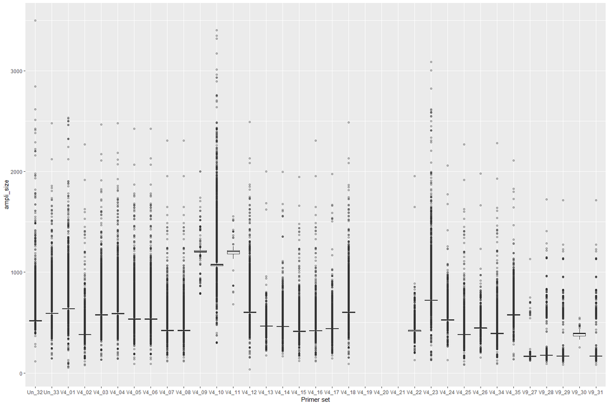

```r
ggplot(pr2_match_final, aes(x = primer_label, y = ampli_size, group = primer_set)) +
    geom_boxplot(outlier.alpha = 0.3) + xlab("Primer set")
```

## 8.2 Plot an example of amplicon distribution

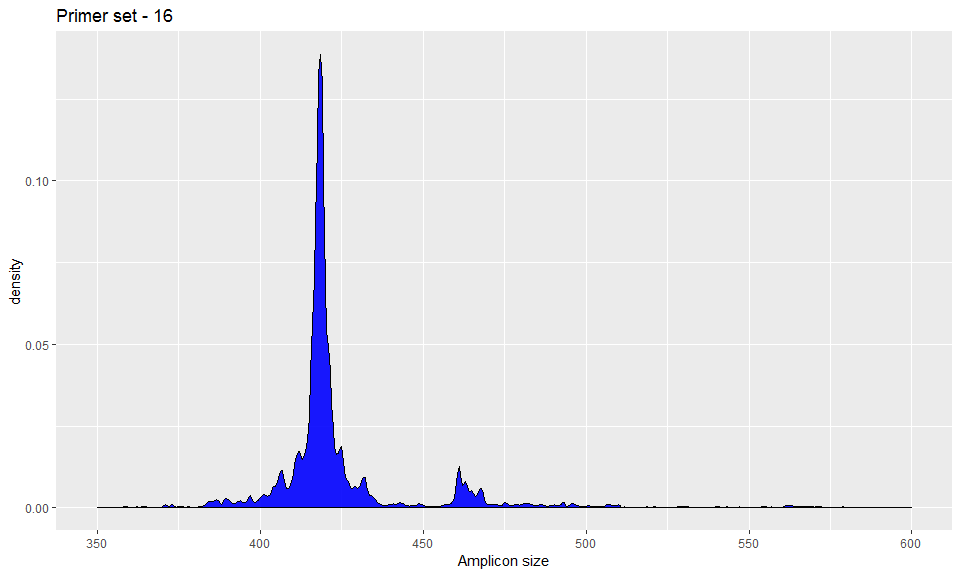

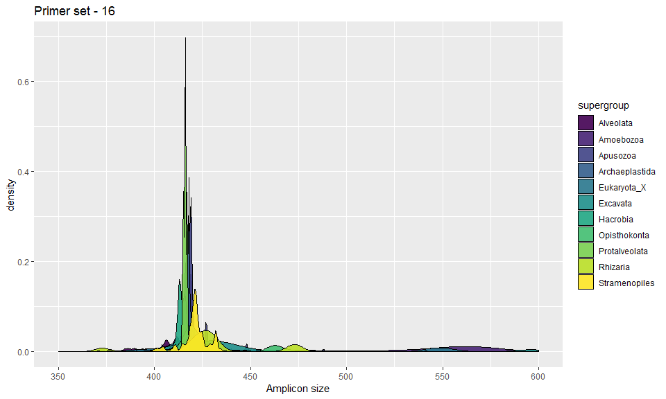

```r
for (one_primer_set in c(16)) {

    g <- ggplot(filter(pr2_match_final, primer_set == one_primer_set), aes(x = ampli_size)) +
        geom_density(fill = "blue", alpha = 0.9) + xlab("Amplicon size") + ggtitle(str_c("Primer set - ",
        one_primer_set)) + xlim(350, 600)

    print(g)

    g <- ggplot(filter(pr2_match_final, primer_set == one_primer_set), aes(x = ampli_size,
        fill = supergroup)) + geom_density(alpha = 0.9) + scale_fill_viridis_d() +
        xlab("Amplicon size") + ggtitle(str_c("Primer set - ", one_primer_set)) +
        xlim(350, 600)

    print(g)
}
```

# 9 Summarize the data in tables

## 9.1 Summarize all eukaryotes

```r
pr2_match_summary_primer_set <- pr2_match_final %>% filter(sequence_length >=
    1500) %>% group_by(region, primer_set) %>% summarize(pct_fwd = sum(!is.na(fwd_pos))/n() *
    100, pct_rev = sum(!is.na(rev_pos))/n() * 100, pct_amplicons = sum(!is.na(ampli_size))/n() *
    100, ampli_size_mean = mean(ampli_size, na.rm = TRUE), ampli_size_sd = sd(ampli_size,
    na.rm = TRUE), ampli_size_max = max(ampli_size, na.rm = TRUE), ampli_size_min = min(ampli_size,
    na.rm = TRUE), n_seq = n())

write_tsv(pr2_match_summary_primer_set, "../primers/pr2_match_summary_primer_set.tsv",
    na = "")

# Long form for Number of sequences

# This dataframe is used to re-order the bars correctly
pct_category_order <- data.frame(pct_category = c("pct_amplicons", "pct_fwd",
    "pct_rev"), pct_category_order = c(3, 1, 2))

pr2_match_summary_primer_set_long <- pr2_match_summary_primer_set %>% tidyr::gather("pct_category",
    "pct_seq", pct_fwd:pct_amplicons) %>% left_join(pct_category_order)
```

## 9.2 Summarize per supergroup

```r
pr2_match_summary_primer_set_sg <- pr2_match_final %>% filter(sequence_length >=
    1500) %>% group_by(supergroup, region, primer_set) %>% summarize(pct_fwd = sum(!is.na(fwd_pos))/n() *
    100, pct_rev = sum(!is.na(rev_pos))/n() * 100, pct_amplicons = sum(!is.na(ampli_size))/n() *
    100, ampli_size_mean = case_when(pct_amplicons > 0 ~ mean(ampli_size, na.rm = TRUE)),
    ampli_size_sd = case_when(pct_amplicons > 0 ~ sd(ampli_size, na.rm = TRUE)),
    ampli_size_max = case_when(pct_amplicons > 0 ~ max(ampli_size, na.rm = TRUE)),
    ampli_size_min = case_when(pct_amplicons > 0 ~ min(ampli_size, na.rm = TRUE)),
    n_seq = n()) %>% ungroup()

write_tsv(pr2_match_summary_primer_set_sg, "../primers/pr2_match_summary_primer_set_per_sg.tsv",
    na = "")
```

## 9.3 Summarize per class

```r
pr2_match_summary_primer_set_class <- pr2_match_final %>% filter(sequence_length >=
    1500) %>% group_by(supergroup, division, class, region, primer_set) %>%
    summarize(pct_fwd = sum(!is.na(fwd_pos))/n() * 100, pct_rev = sum(!is.na(rev_pos))/n() *
        100, pct_amplicons = sum(!is.na(ampli_size))/n() * 100, ampli_size_mean = case_when(pct_amplicons >
        0 ~ mean(ampli_size, na.rm = TRUE)), ampli_size_sd = case_when(pct_amplicons >
        0 ~ sd(ampli_size, na.rm = TRUE)), ampli_size_max = case_when(pct_amplicons >
        0 ~ max(ampli_size, na.rm = TRUE)), ampli_size_min = case_when(pct_amplicons >
        0 ~ min(ampli_size, na.rm = TRUE)), n_seq = n())

write_tsv(pr2_match_summary_primer_set_class, "../primers/pr2_match_summary_primer_set_per_class.tsv",
    na = "")
```

# 10 Graphics

## 10.1 All Eukaryotes

Comments

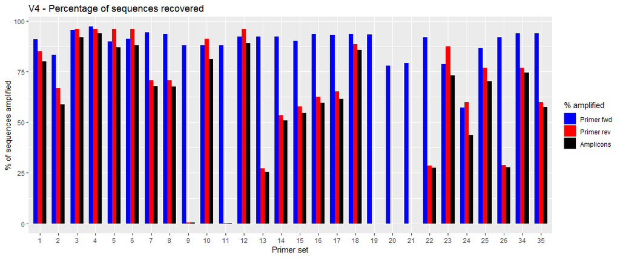

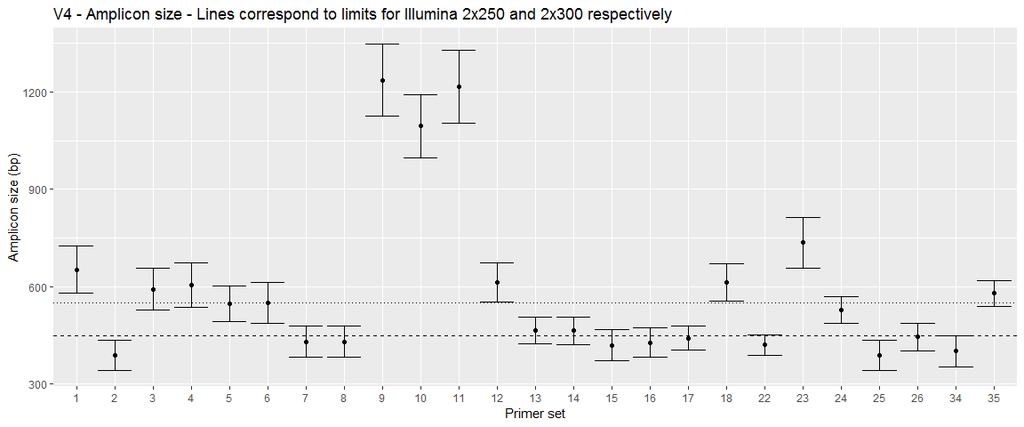

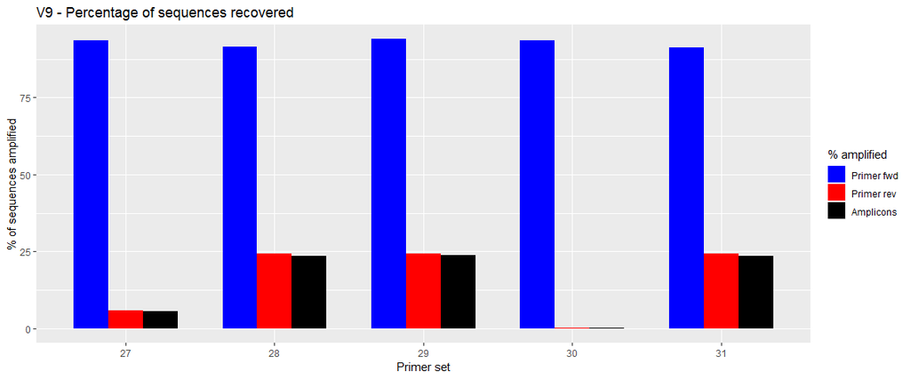

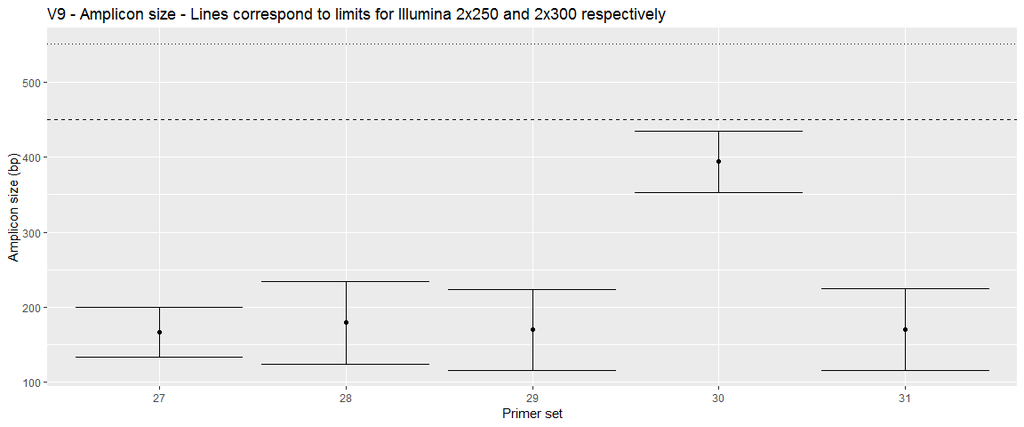

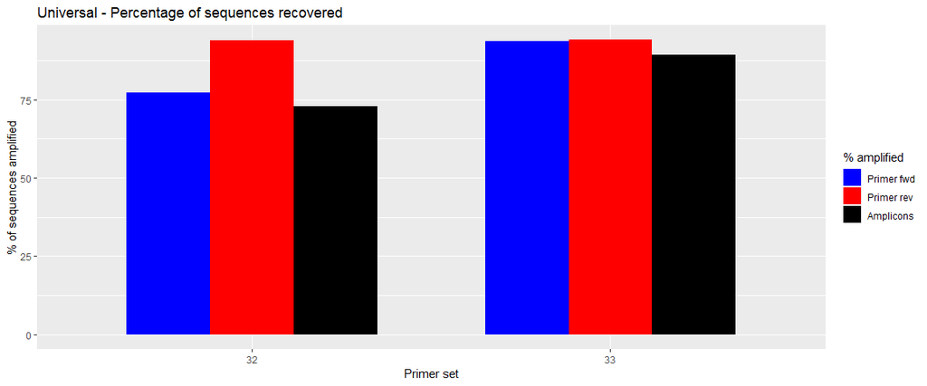

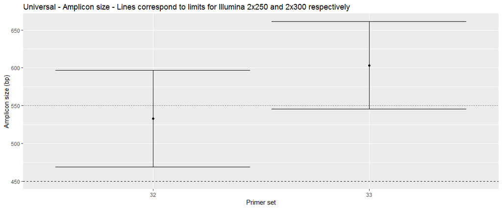

```r
for (one_region in c("V4", "V9", "Universal")) {

    pr2_match_summary_primer_set_region_long <- filter(pr2_match_summary_primer_set_long,
        region == one_region)
    pr2_match_summary_primer_set_region <- filter(pr2_match_summary_primer_set,
        region == one_region)

    g <- ggplot(pr2_match_summary_primer_set_region_long) + geom_col(aes(x = reorder(as.character(primer_set),
        primer_set), y = pct_seq, fill = fct_reorder(pct_category, pct_category_order)),
        width = 0.7, position = "dodge") + xlab("Primer set") + ylab("% of sequences amplified") +
        scale_fill_manual(name = "% amplified", values = c(pct_amplicons = "black",
            pct_fwd = "blue", pct_rev = "red"), labels = c("Primer fwd", "Primer rev",
            "Amplicons")) + ggtitle(str_c(one_region, " - Percentage of sequences recovered"))
    print(g)


    g <- ggplot(filter(pr2_match_summary_primer_set_region, !is.nan(ampli_size_mean))) +
        geom_point(aes(x = reorder(as.character(primer_set), primer_set), y = ampli_size_mean),
            colour = "black") + geom_errorbar(aes(x = reorder(as.character(primer_set),
        primer_set), ymax = ampli_size_mean + ampli_size_sd, ymin = ampli_size_mean -
        ampli_size_sd)) + xlab("Primer set") + ylab("Amplicon size (bp)") +
        # scale_y_continuous(breaks = (1:8)*200, limits = c(0,1500)) +
    ggtitle(str_c(one_region, " - Amplicon size - Lines correspond to limits for Illumina 2x250 and 2x300 respectively")) +
        geom_hline(yintercept = c(450, 550), linetype = c(2, 3))
    print(g)
}
```

## 10.2 By supergroup

Comments

- Excavata have a very different patterns from the rest of the group. They are not amplified by quite a few primer sets. They have also bigger amplicons
- Some groups exhibit higher variability in amplicon size (e.g Chlorophyta)

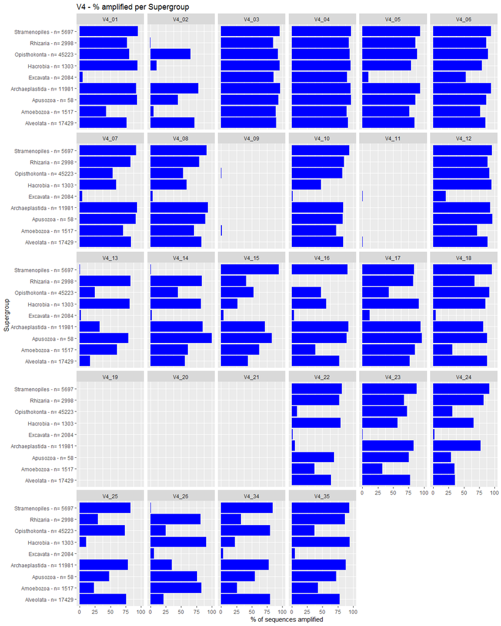

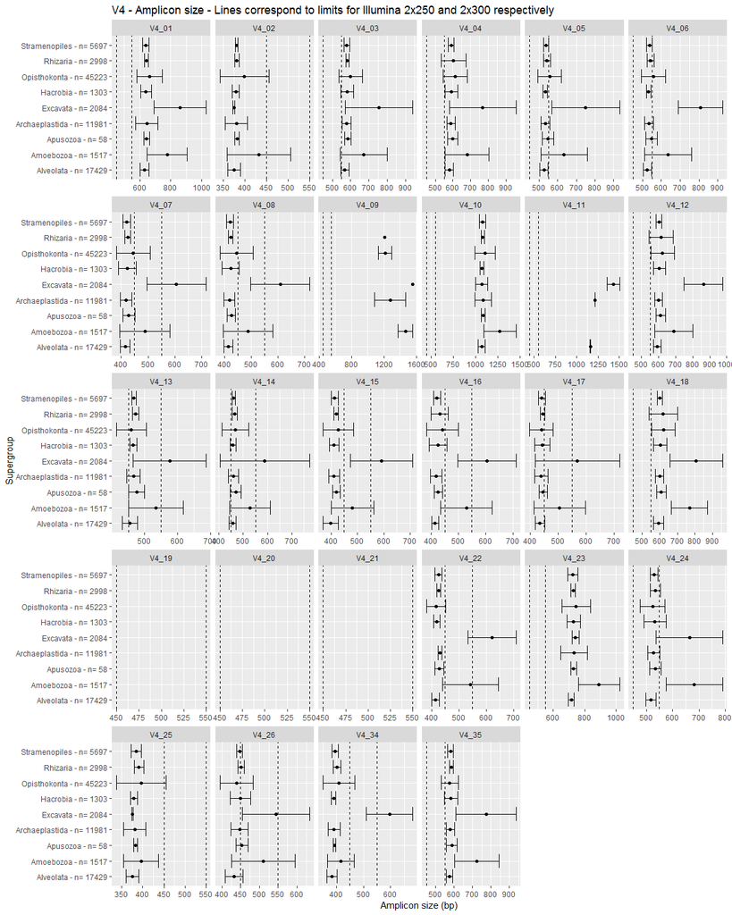

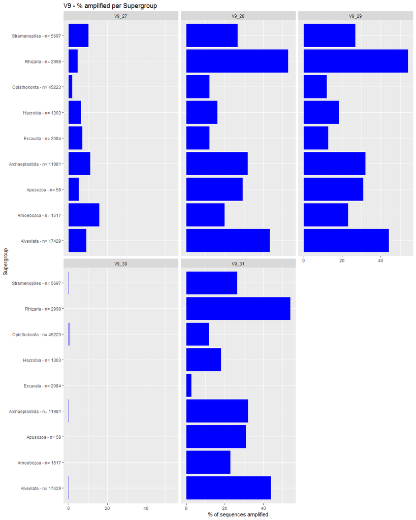

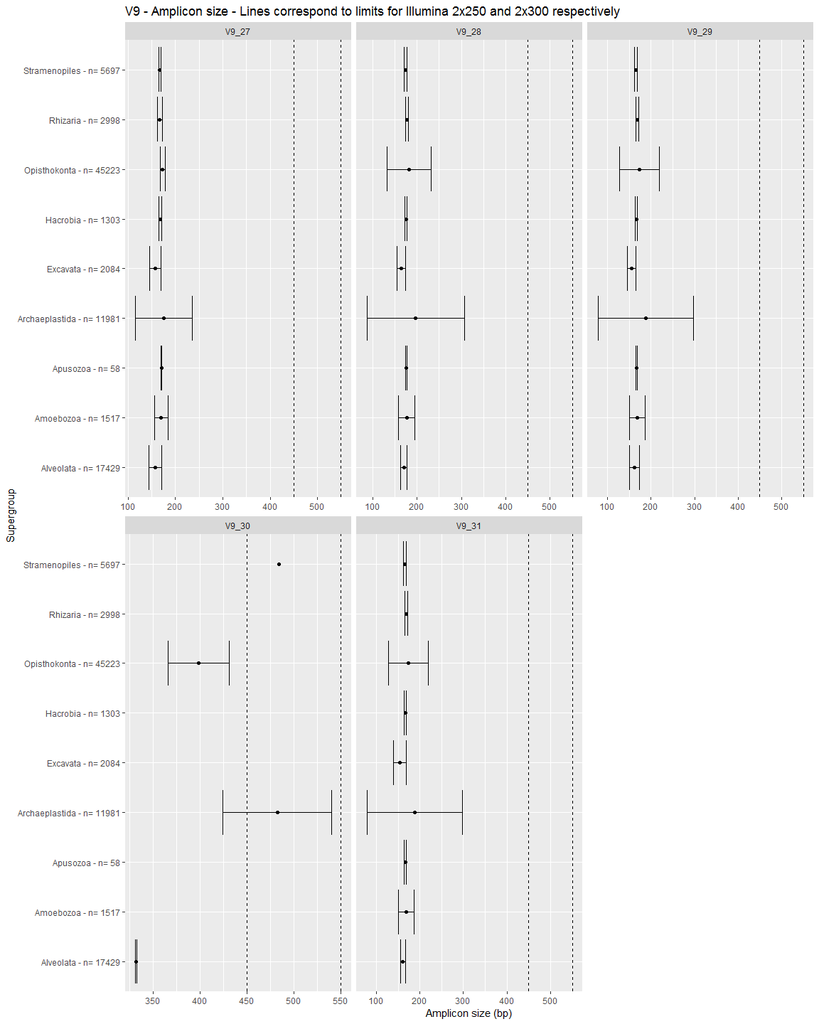

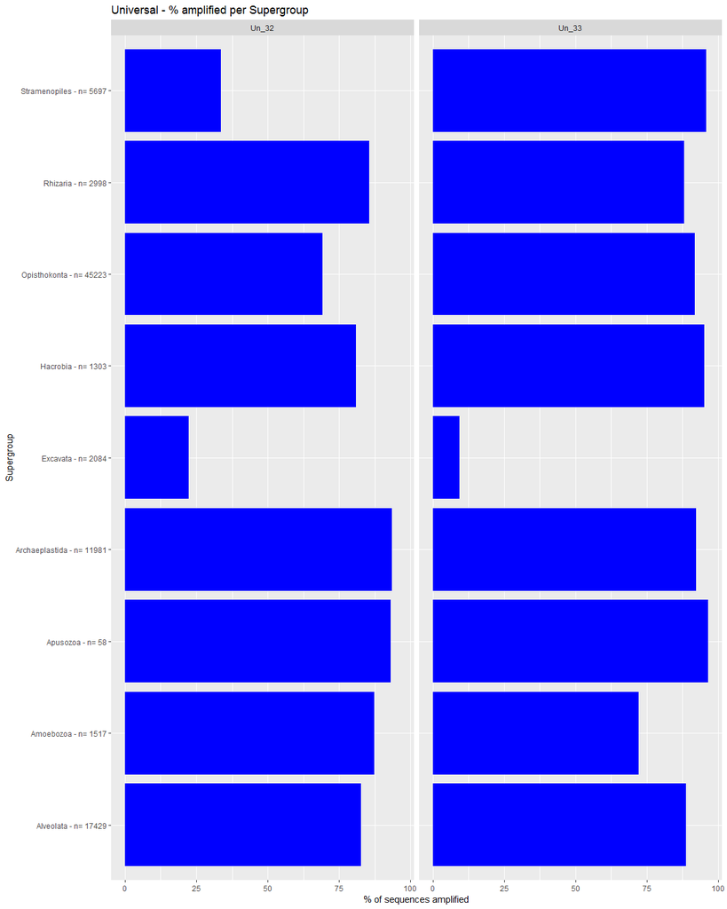

[figure not shown]

```r
for (one_region in c("V4", "V9", "Universal")) {

    pr2_match_summary_primer_set_sg_region <- filter(pr2_match_summary_primer_set_sg,
        (region == one_region) & (n_seq > 20)) %>% mutate(primer_label = str_c(str_sub(region,
        1, 2), sprintf("%02d", primer_set), sep = "_"))

    g <- ggplot(pr2_match_summary_primer_set_sg_region) + geom_col(aes(x = str_c(supergroup,
        " - n= ", n_seq), y = pct_amplicons), fill = "blue", position = "dodge") +
        coord_flip() + ylab("% of sequences amplified") + xlab("Supergroup") +
        ggtitle(str_c(one_region, " - % amplified per Supergroup")) + facet_wrap(~primer_label)

    print(g)

    g <- ggplot(filter(pr2_match_summary_primer_set_sg_region, !is.nan(ampli_size_mean))) +
        geom_point(aes(x = str_c(supergroup, " - n= ", n_seq), y = ampli_size_mean),
            colour = "black") + coord_flip() + geom_errorbar(aes(x = str_c(supergroup,
        " - n= ", n_seq), ymax = ampli_size_mean + ampli_size_sd, ymin = ampli_size_mean -
        ampli_size_sd)) + xlab("Supergroup") + ylab("Amplicon size (bp)") +
        ggtitle(str_c(one_region, " - Amplicon size - Lines correspond to limits for Illumina 2x250 and 2x300 respectively")) +
        geom_hline(yintercept = c(450, 550), linetype = 2) + facet_wrap(~primer_label,
        scales = "free_x")

    print(g)



}
```

## 10.3 By class for autotrophs

Comments

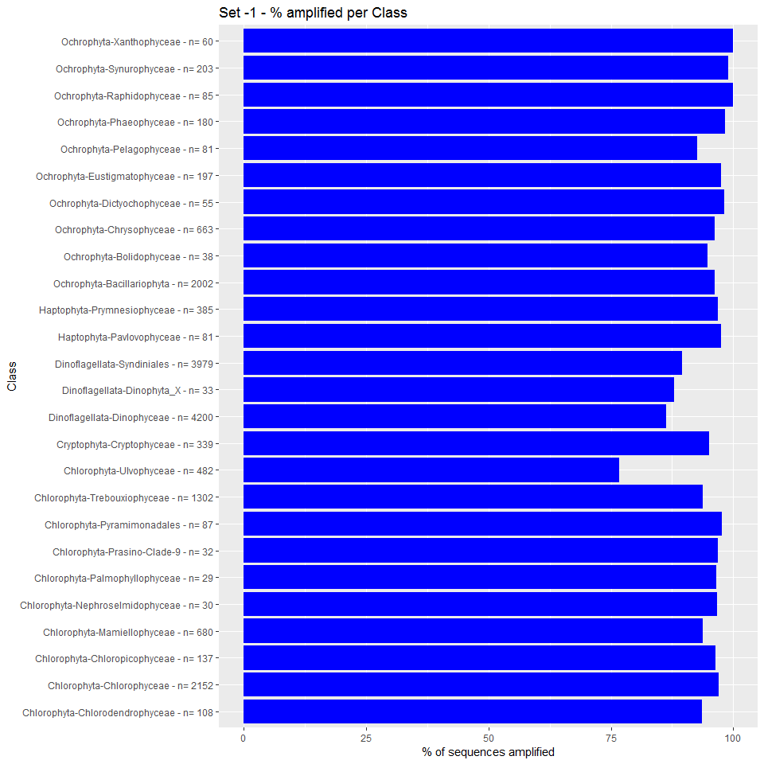

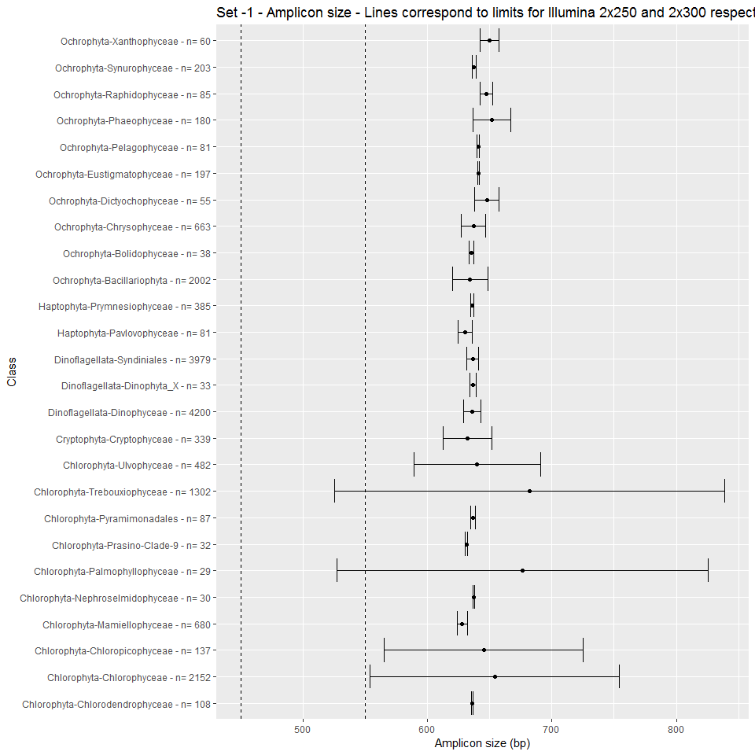

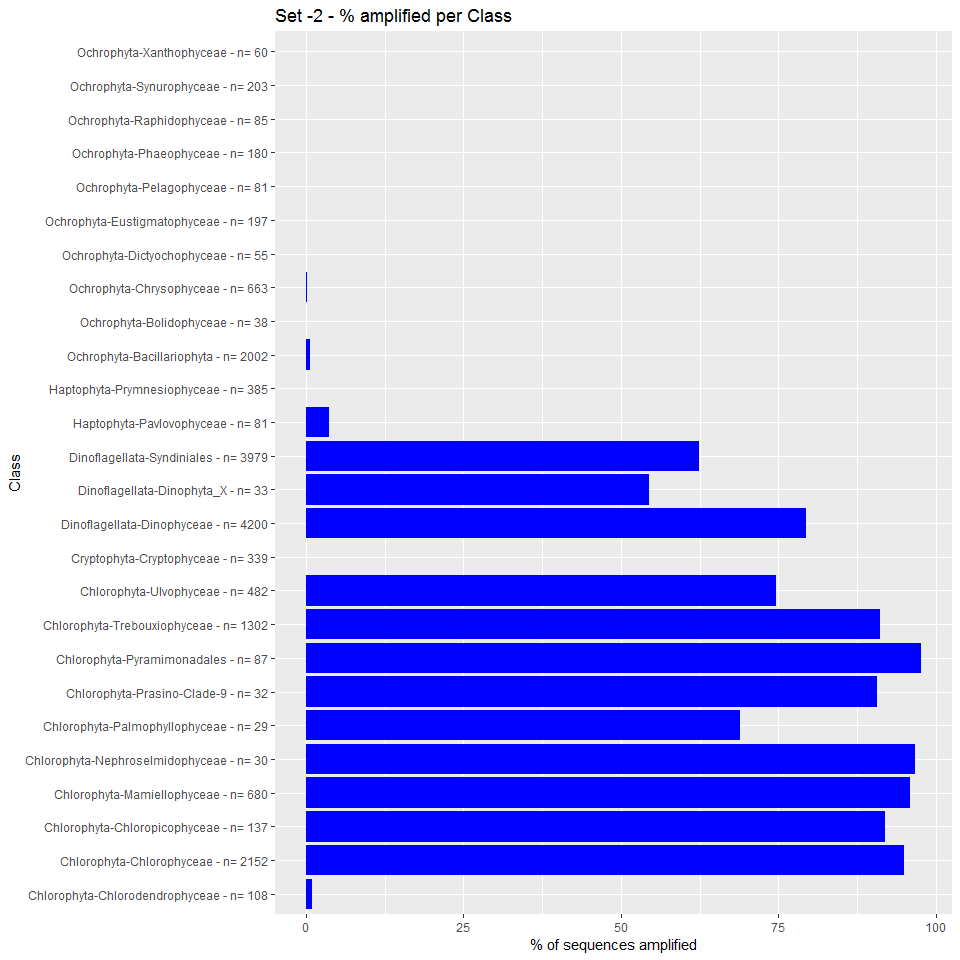

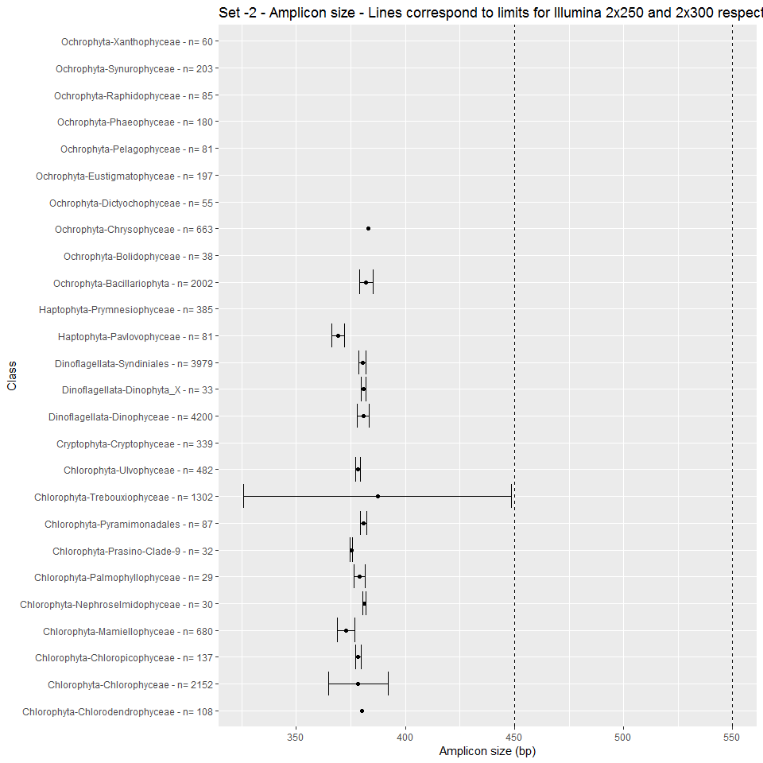

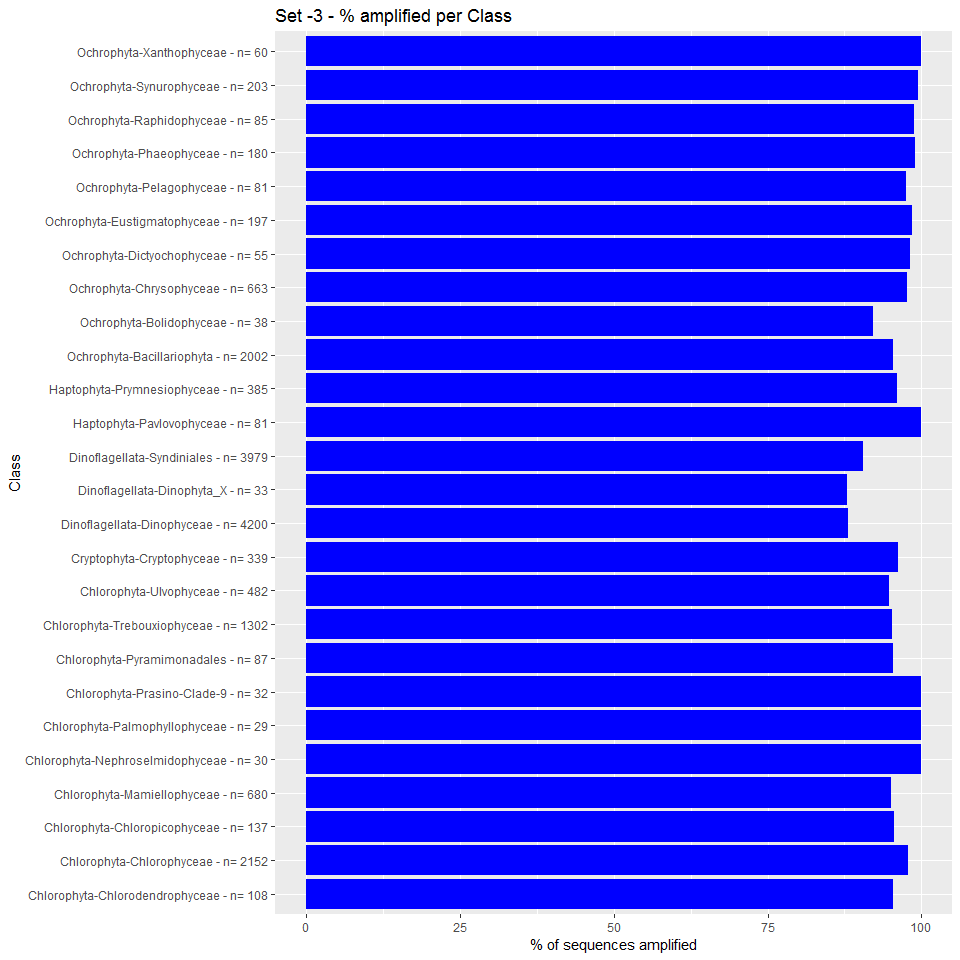

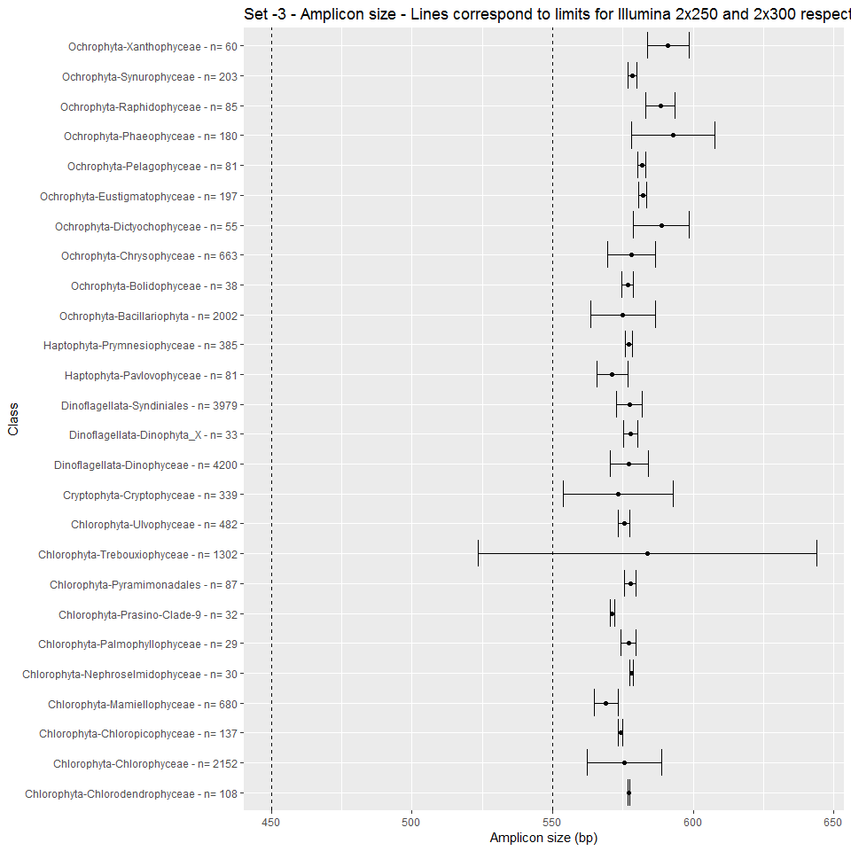

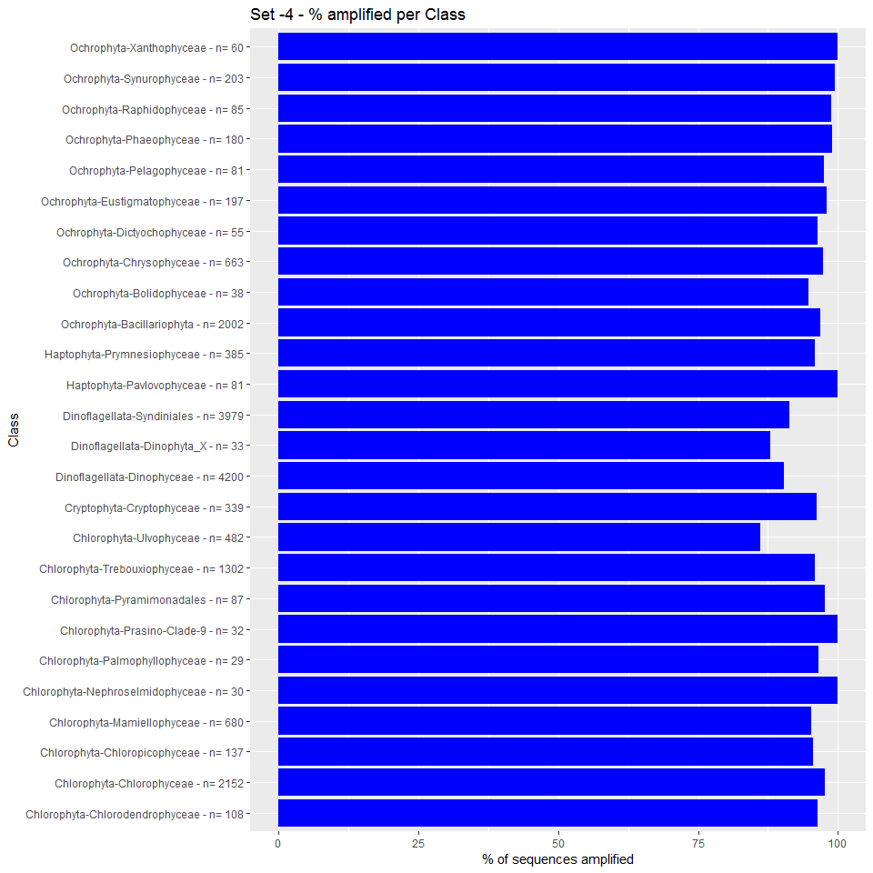

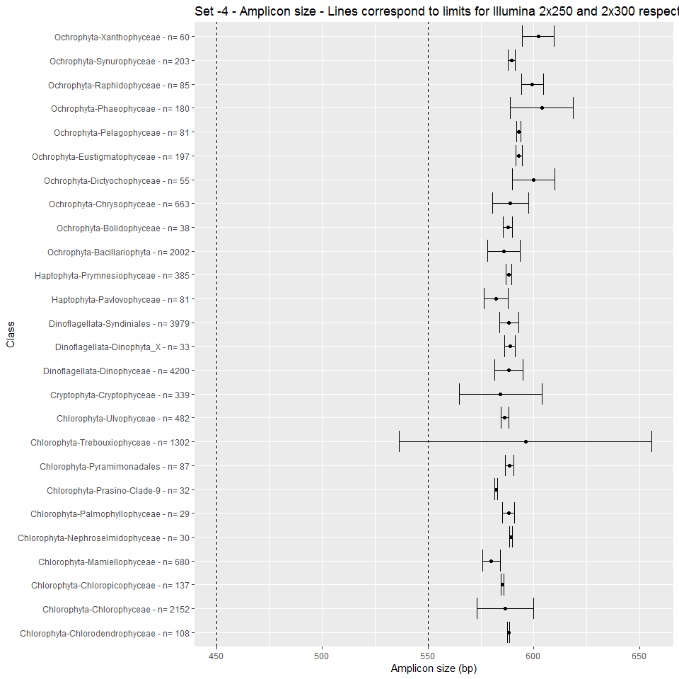

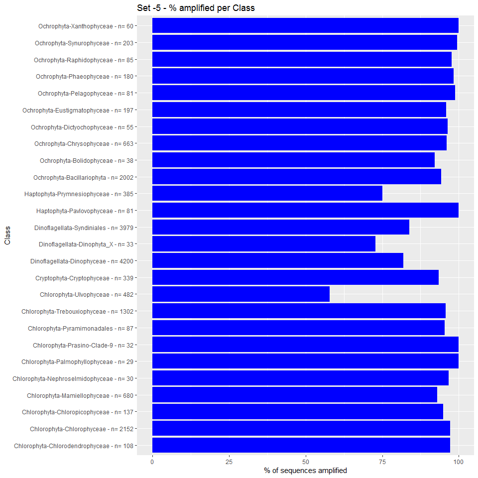

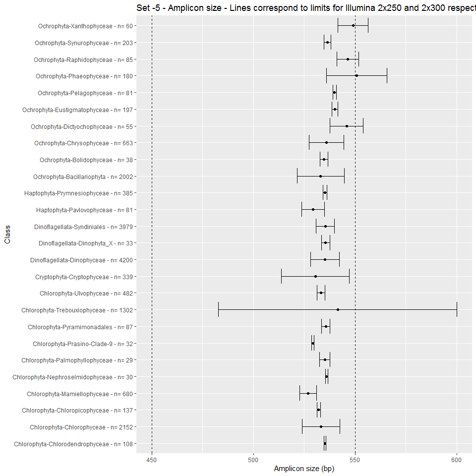

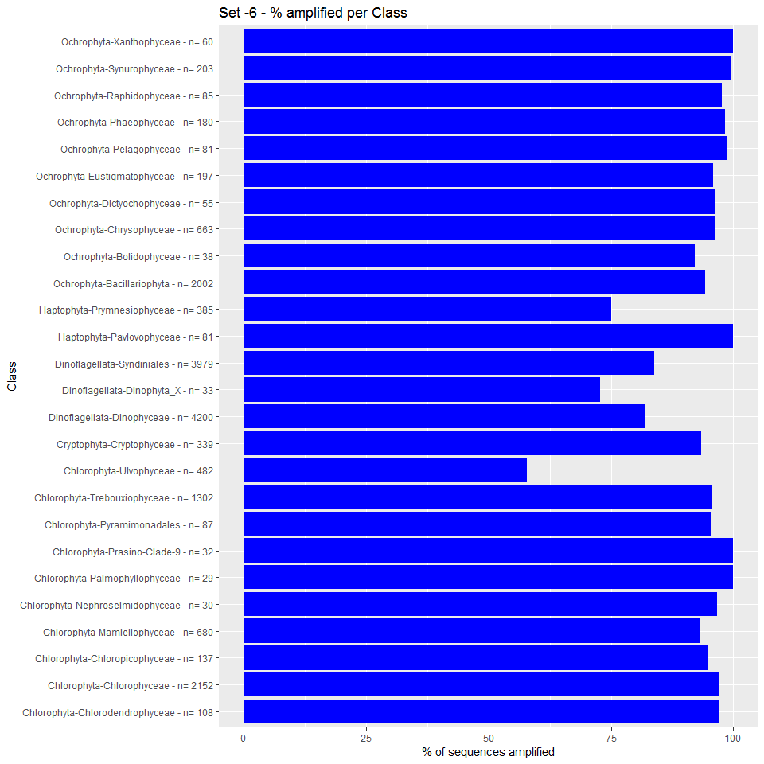

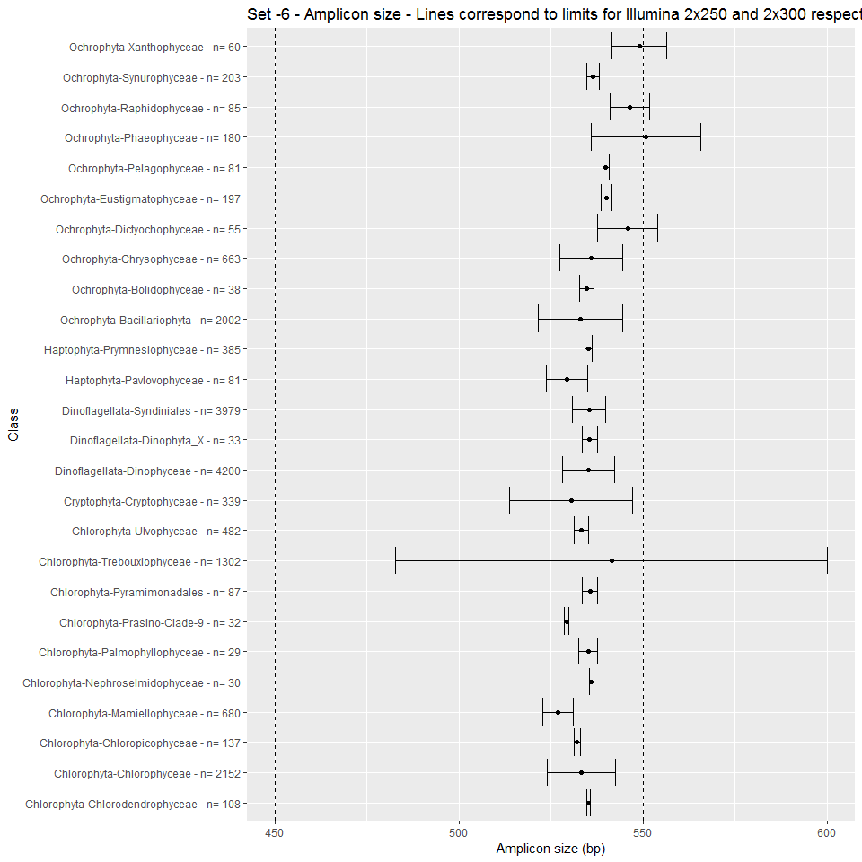

[58 more figures not shown]

```r
for (one_primer_set in 1:nrow(primer_sets)) {

    pr2_match_summary_filtered <- filter(pr2_match_summary_primer_set_class,
        (n_seq > 20) & (division %in% c("Haptophyta", "Dinoflagellata", "Chlorophyta",
            "Ochrophyta", "Cryptophyta")) & (primer_set == one_primer_set)) %>%
        mutate(primer_label = str_c(str_sub(region, 1, 2), sprintf("%02d", primer_set),
            sep = "_"))

    g <- ggplot(pr2_match_summary_filtered) + geom_col(data = pr2_match_summary_filtered,
        aes(x = str_c(division, "-", class, " - n= ", n_seq), y = pct_amplicons),
        fill = "blue", position = "dodge") + coord_flip() + ylab("% of sequences amplified") +
        xlab("Class") + ggtitle(str_c("Set -", one_primer_set, " - % amplified per Class"))

    print(g)

    g <- ggplot(filter(pr2_match_summary_filtered, !is.nan(ampli_size_mean))) +
        geom_point(aes(x = str_c(division, "-", class, " - n= ", n_seq), y = ampli_size_mean),
            colour = "black") + coord_flip() + geom_errorbar(aes(x = str_c(division,
        "-", class, " - n= ", n_seq), ymax = ampli_size_mean + ampli_size_sd,
        ymin = ampli_size_mean - ampli_size_sd)) + xlab("Class") + ylab("Amplicon size (bp)") +
        # scale_y_continuous(breaks = (1:8)*200, limits = c(0,1500)) +
    ggtitle(str_c("Set -", one_primer_set, " - Amplicon size - Lines correspond to limits for Illumina 2x250 and 2x300 respectively")) +
        geom_hline(yintercept = c(450, 550), linetype = 2)

    print(g)

}
```